# Dye Order & Distinguishing Power

Hanxi Tang, Bin He

2024-01-17 (updated 2024-01-27 15:11:13.50325)

# Background

This is the flow cytometry data for miglog phase Cg stained with PI/PI+SYTO9/ SYTO+PI in different staining orders, and run through flow cytometry (details in ELN). The goal is to establish FungaLight’s distinguishing power with different staining protocols.

```r
require(tidyverse)
require(flowCore)
require(flowClust)
require(openCyto)
require(ggcyto)
require(cowplot)
require(ggridges)
```

```r
old <- theme_set(theme_minimal())
```

# Import data

> FCS files are stored in RDSS/user/flow cytometry, FCS is read and write into an input tsv table. The tsv file is avaliable from the Input folder.

```r
# use relative path to make it easier for collaboration
data.path = "/Volumes/rdss_bhe2/User/Hanxi Tang/Flow Cytometry/20240109_0116 Dye order/"
dat0 <- read.flowSet(path = data.path, transformation = FALSE,  # the original values are already linearized.
                     emptyValue = FALSE,  alter.names = TRUE,   # change parameter names to R format
                     column.pattern = ".H|FSC|SSC") # only load the height variables for the fluorescent parameters
```

## Simplify the sample names

```r
#require(PTXQC)
#source("../script/20220326-simplify-names-subroutine.R")
oriNames <- sampleNames(dat0)
tmp <- str_split(oriNames, pattern = "[ _]+", simplify = TRUE)[,c(1, 6, 7)]
colnames(tmp) <- c("Date", "Treatment", "Dye")
sample <- data.frame(tmp) %>%
  mutate(
    Dye = case_match(
      Dye,
      "p.fcs" ~ "PI alone",
      "pf.fcs" ~ "PI first",
      "sf.fcs" ~ "SYTO9+PI",
      .default = NA
    )
  )
rownames(sample) <- oriNames
pData(dat0) <- sample
dat <- dat0[!is.na(sample$Dye)]
print(pData(dat) %>% as_tibble())
```

| Date | Treatment | Dye | name |
| --- | --- | --- | --- |
| 011124 | 0 | PI alone | 011124_Dye Order_Experiment_Plate_0_p.fcs |
| 011124 | 0 | PI first | 011124_Dye Order_Experiment_Plate_0_pf.fcs |
| 011124 | 0 | SYTO9+PI | 011124_Dye Order_Experiment_Plate_0_sf.fcs |
| 011124 | 10 | PI alone | 011124_Dye Order_Experiment_Plate_10_p.fcs |
| 011124 | 10 | PI first | 011124_Dye Order_Experiment_Plate_10_pf.fcs |
| 011124 | 10 | SYTO9+PI | 011124_Dye Order_Experiment_Plate_10_sf.fcs |
| 011124 | 100 | PI alone | 011124_Dye Order_Experiment_Plate_100_p.fcs |
| 011124 | 100 | PI first | 011124_Dye Order_Experiment_Plate_100_pf.fcs |
| 011124 | 100 | SYTO9+PI | 011124_Dye Order_Experiment_Plate_100_sf.fcs |
| 011124 | 1000 | PI alone | 011124_Dye Order_Experiment_Plate_1000_p.fcs |

[output cut: 26 more lines]

```r
write_tsv(pData(dat), file = "../data/10.01-sample-list.tsv")
```

# Basic gating

## Outlier

The following gaphing steps are used to gate singlets by FSC and SSC values. Only singlets are included in analysis.

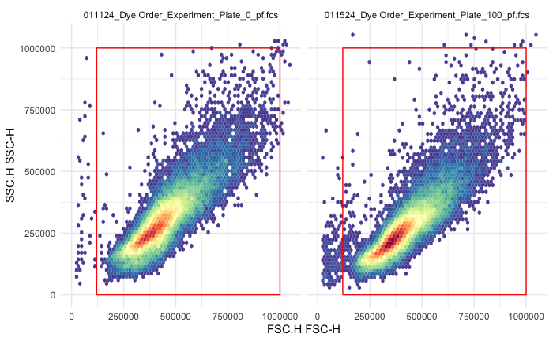

```r
outlier.gate <- rectangleGate(filterId = "-outlier", "FSC.H" = c(1.2e5, 1e6), "SSC.H" = c(1e2, 1e6))
ggcyto(dat[c(2,20)], aes(x = FSC.H, y = SSC.H), subset = "root") +
  geom_hex(bins = 64) + geom_gate(outlier.gate) + facet_wrap(~name, ncol = 2) + ggcyto_par_set(limits = "instrument")
```

Add gate to GS

```r
# shorten the names of the samples for plotting
shortNames <- with(pData(dat),
                   paste(substr(Date, 1, 4), paste0(Treatment, " mM")
                         , Dye, sep = "_"))
names(shortNames) <- sampleNames(dat)
gs <- GatingSet(dat) # create a GatingSet
# rename the GatingSet
if(all(sampleNames(gs) == names(shortNames)))
  pData(gs)$name <- shortNames
# repair the Date column in pData
pData(gs)$Date = paste0("0", pData(gs)$Date)
# add the outlier gate
gs_pop_add(gs, outlier.gate, parent = "root")
```

```
[1] 2
```

```r
# compute
recompute(gs)
```

```
done!
```

## Gate for singlets

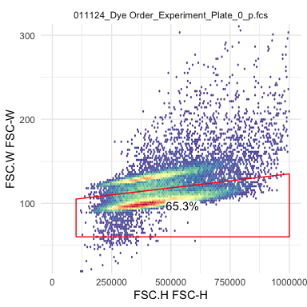

```r
scPars <- ggcyto_par_set(limits = list(x = c(0,1e6), y = c(30,300)))
ex <- Subset(dat[[1]], outlier.gate)
polygon <- matrix(c(1e5, 1e5, 1e6, 1e6,
                    60, 105, 135,60), ncol = 2)
colnames(polygon) <- c("FSC.H", "FSC.W")
singlet.gate <- polygonGate(filterId = "singlet", .gate = polygon)
ggcyto(ex, aes(x = FSC.H, y = FSC.W)) + geom_hex(bins = 128) + geom_gate(singlet.gate) + geom_stats() + scPars
```

Add this gate to the gatingSet

```r
gs_pop_add(gs, singlet.gate, parent = "-outlier", name = "singlet")
```

```
[1] 3
```

```r
recompute(gs)
```

```
done!
```

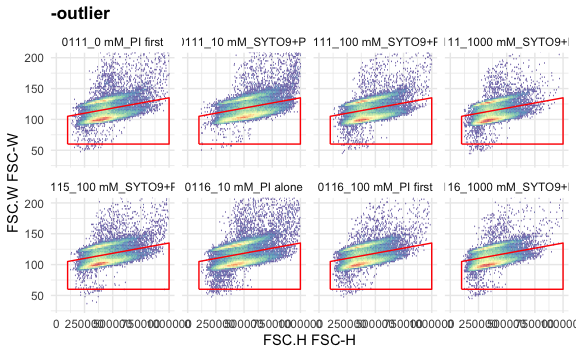

```r
scPars <- ggcyto_par_set(limits = list(x = c(0,1e6), y = c(30,200)))
test <- sample(1:length(gs), 8)
ggcyto(gs[test], aes(x = FSC.H, y = FSC.W), subset = "-outlier") +
  geom_hex(bins = 128) + geom_gate("singlet") + facet_wrap(~name, ncol = 4) +
  scPars# + theme(strip.text = element_blank())
```

## FSC and SSC vs treatment and dye

### FSC

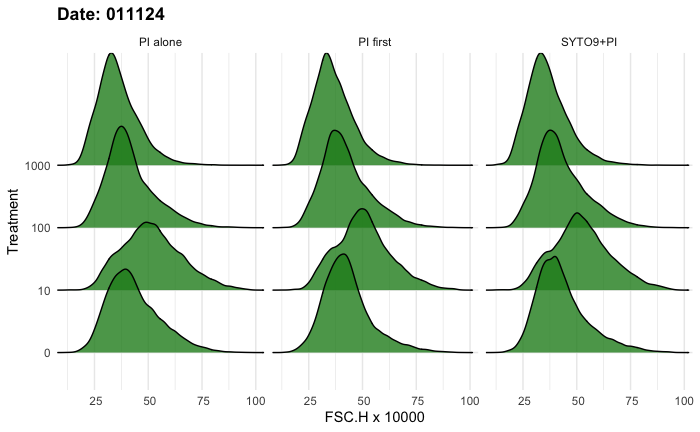

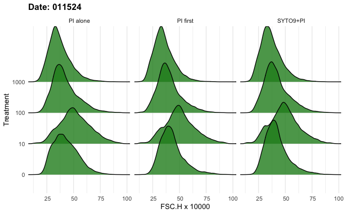

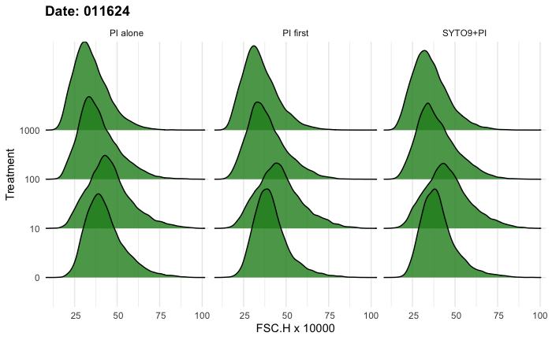

```r
mult_format <- function() {
     function(x) format(x/10000,digits = 2)
}
for(date in c("011124", "011524", "011624")){
  p <- ggcyto(gs[pData(gs)$Date == date], aes(x = FSC.H), subset = "singlet") +
    geom_density_ridges(aes(y = Treatment), fill = "forestgreen", alpha = 0.8) +
    scale_x_continuous(labels = mult_format(), name = "FSC.H x 10000") +
    facet_wrap(~Dye) + labs(title = paste0("Date: ", date))
  print(p)
}
```

> Mock treated sample stands out - the three H2O2 treated samples show a trend of decreasing FSC with increasing ROS Mock has a FSC in between 10 and 100 mM

### FSC vs BL1.H (green staining)

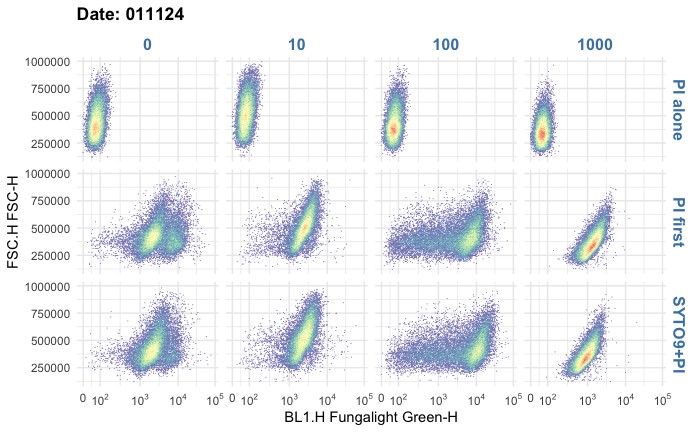

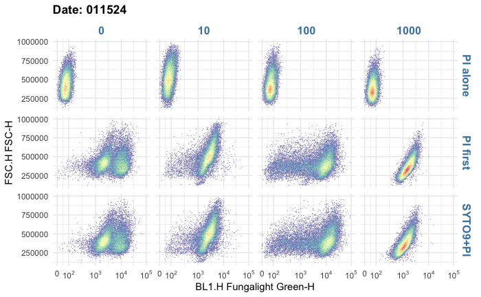

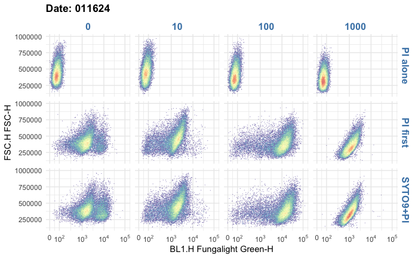

```r
for(date in c("011124", "011524", "011624")){
  p <- ggcyto(gs[pData(gs)$Date == date], aes(x = BL1.H, y = FSC.H), subset = "singlet") +
    geom_hex(bins = 128) +
    #geom_gate(live.gate) +
    #geom_stats(location = "data", adjust = c(0.1, 0.8), digits = 2) +
    labs(title = paste0("Date: ", date)) +
    facet_grid(Dye ~ Treatment) +
    scale_x_logicle() + #scale_y_logicle() +
    theme(strip.text = element_text(size = rel(1.1), color = "steelblue", face = 2))
  print(p)
}
```

### SSC

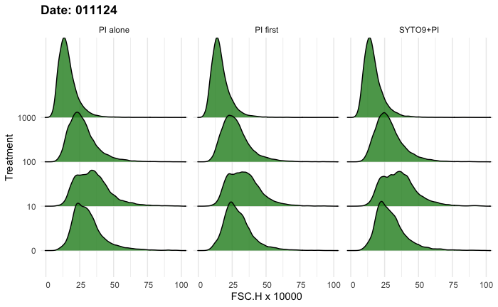

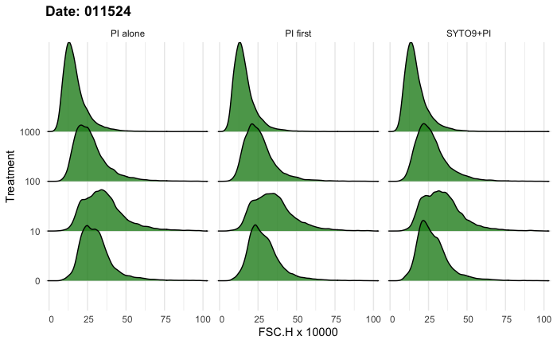

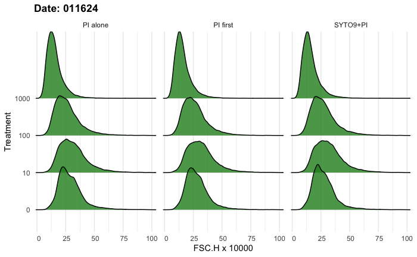

```r
for(date in c("011124", "011524", "011624")){
  p <- ggcyto(gs[pData(gs)$Date == date], aes(x = SSC.H), subset = "singlet") +
    geom_density_ridges(aes(y = Treatment), fill = "forestgreen", alpha = 0.8) +
    scale_x_continuous(labels = mult_format(), name = "FSC.H x 10000") +
    facet_wrap(~Dye) + labs(title = paste0("Date: ", date))
  print(p)
}
```

> SSC (complexity of cell, roughly) decreases with increasing H2O2 concentration Mock again show a different pattern.

# Gate for scoring

## Live = red negative

This is the live population with red fluorescence below 10^2.2

> Important: I changed the Red top boundary to 10^2.3 from 10^2.2

> **Main takeaway**
> 1. From 10mM to 1M treated samples, %live decreases and the change is much more obvious in the dual stain (PI first or simultaneous) than PI alone
> 2. The mock treated sample has a visible high red high green (not as high and prominent as the 100 mM treated) than 10 mM treated. It doesn’t follow the trend above.

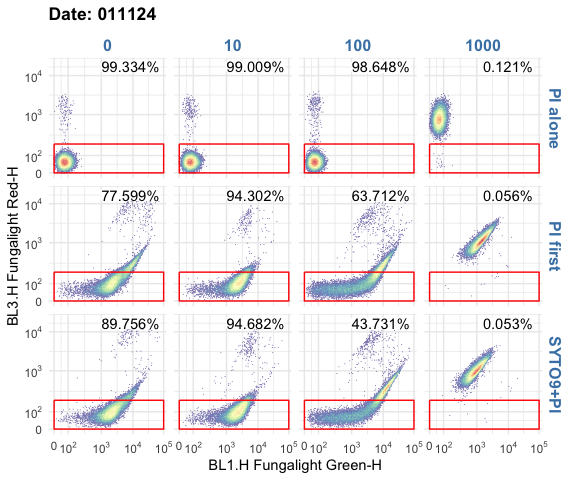

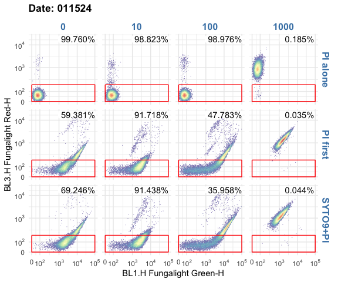

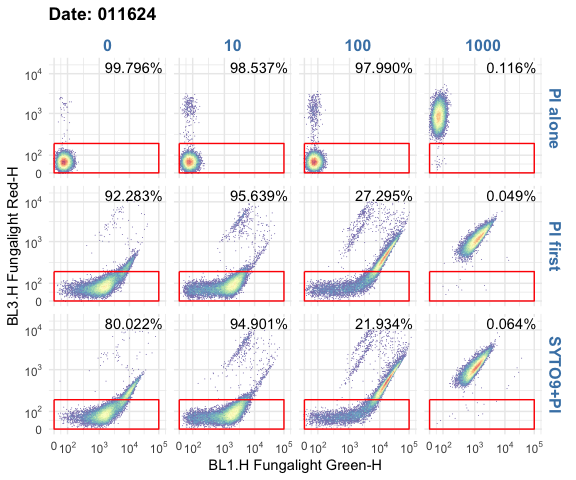

```r
#scPars <- ggcyto_par_set(limits = list(x = c(0,1e6), y = c(0,1e5)))
polygon <- matrix(c(0, 10^5, 10^5, 0,
                    10^2.3, 10^2.3, 0, 0), ncol = 2)
colnames(polygon) <- c("BL1.H", "BL3.H")
live.gate <- polygonGate(filterId = "live", .gate = polygon)
for(date in c("011124", "011524", "011624")){
  p <- ggcyto(gs[pData(gs)$Date == date], aes(x = BL1.H, y = BL3.H), subset = "singlet") +
    geom_hex(bins = 128) +
    geom_gate(live.gate) +
    geom_stats(location = "data", adjust = c(0.1, 0.8), digits = 2) +
    labs(title = paste0("Date: ", date)) +
    facet_grid(Dye ~ Treatment) +
    scale_x_logicle() + scale_y_logicle() +
    theme(strip.text = element_text(size = rel(1.1), color = "steelblue", face = 2))
  print(p)
}
```

> Notice the higher percentage of events in the live gate in 10 mM vs mock.

## Intermediate = high G/R

> Important: I changed the bottom boundary from 10^2.2 to 10^2.3, and the left boundary from 10^3 to 2*10^3

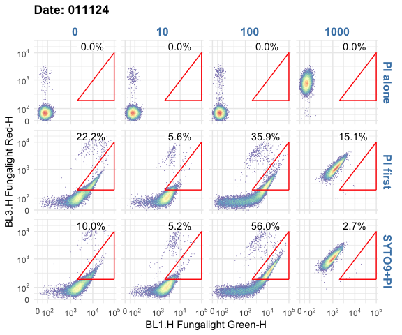

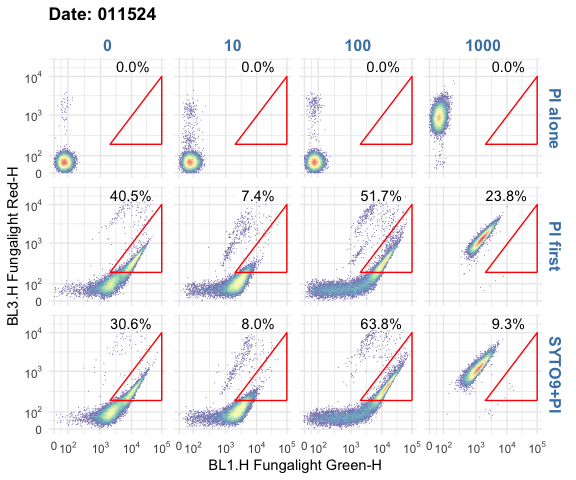

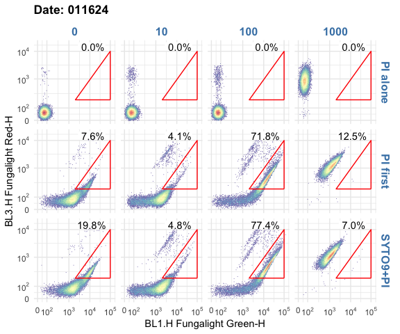

```r
#scPars <- ggcyto_par_set(limits = list(x = c(0,1e6), y = c(0,1e6)))
#ex <- Subset(dat.f1g[[9]], singlet.gate)
polygon <- matrix(c(10^5, 2*10^3, 10^5,
                    10^2.3, 10^2.3, 10^4), ncol = 2)
colnames(polygon) <- c("BL1.H", "BL3.H")
inter.gate <- polygonGate(filterId = "inter", .gate = polygon)
for(date in c("011124", "011524", "011624")){
  p <- ggcyto(gs[pData(gs)$Date == date], aes(x = BL1.H, y = BL3.H), subset = "singlet") +
    geom_hex(bins = 128) +
    geom_gate(inter.gate) +
    geom_stats(location = "data",  adjust = c(0.1, 0.8), digits = 2) +
    labs(title = paste0("Date: ", date)) +
    facet_grid(Dye ~ Treatment) +
    scale_x_logicle() + scale_y_logicle() +
    theme(strip.text = element_text(size = rel(1.1), color = "steelblue", face = 2))
  print(p)
}
```

## Dead = High red low green

We don’t need to set the dead gate because all we want is the percent of events in that gate, not the MFI for either channel. The percentage can be calculated by subtracting the percent of events in the previous two gates from 100%.

# Exported gate stats

% of events in each of the three gates

```r
gated_stats <- gs_pop_get_stats(gs, type = "count") %>%
  as_tibble() %>%
  mutate(pop = gsub(".*/", "", pop), pop = gsub("-outlier", "cells", pop)) %>%
  pivot_wider(names_from = pop, names_prefix = "n_", values_from = count) %>%
  mutate(
    #p_singlet = n_singlet / n_cells,
    p_live = n_live / n_singlet,
    p_intermediate = n_intermediate / n_singlet,
    p_dead = 1 - p_live - p_intermediate
  )
#write_tsv(gated_data, file = "../Input/20240124-fig-2-Dye-Order-gated-ht.tsv")
#print(gated_data)
```

MFI in the live and intermediate gates

```r
popMFI <- gs_pop_get_stats(gs, nodes = c("live", "intermediate"), type = pop.MFI) %>%
  as_tibble() %>%
  select(sample, pop, FSC = `FSC-H`, BL1 = `Fungalight Green-H`) %>%
  pivot_wider(names_from = pop, values_from = c(FSC, BL1))
```

Combine the data and meta data

```r
final <- select(pData(dat), sample = name, everything()) %>%
  left_join(select(gated_stats, -starts_with("n_")),  by = "sample") %>%
  left_join(popMFI, by = "sample")

write_tsv(final, file = "../data/12.01-gated-output-20240117.tsv")
print(final %>% select(-sample))
```

| Date | Treatment | Dye | p_live | p_intermediate | p_dead | FSC_live | FSC_intermediate | BL1_live | BL1_intermediate |
| --- | --- | --- | --- | --- | --- | --- | --- | --- | --- |
| 011124 | 0 | PI alone | 0.9933428923 | 0.0000000000 | 0.006657108 | 414660.0 | NaN | 73.0 | NaN |
| 011124 | 0 | PI first | 0.7759888895 | 0.2132606347 | 0.010750476 | 412039.0 | 436111.0 | 2132.0 | 8942.0 |
| 011124 | 0 | SYTO9+PI | 0.8975578475 | 0.0951210388 | 0.007321114 | 405841.5 | 482793.0 | 2059.0 | 7509.5 |
| 011124 | 10 | PI alone | 0.9900889317 | 0.0000000000 | 0.009911068 | 508718.0 | NaN | 77.0 | NaN |
| 011124 | 10 | PI first | 0.9430183969 | 0.0477017420 | 0.009279861 | 493254.0 | 670491.0 | 2385.0 | 4872.0 |
| 011124 | 10 | SYTO9+PI | 0.9468230992 | 0.0417999898 | 0.011376911 | 510842.5 | 687909.0 | 2280.0 | 4942.0 |
| 011124 | 100 | PI alone | 0.9864794592 | 0.0000000000 | 0.013520541 | 396592.0 | NaN | 71.0 | NaN |
| 011124 | 100 | PI first | 0.6371223326 | 0.3443904500 | 0.018487217 | 380278.5 | 455175.5 | 2061.5 | 9484.0 |
| 011124 | 100 | SYTO9+PI | 0.4373083662 | 0.5473609286 | 0.015330705 | 380901.0 | 435343.0 | 1397.0 | 11872.0 |
| 011124 | 1000 | PI alone | 0.0012065890 | 0.0000000000 | 0.998793411 | 305405.0 | NaN | 76.0 | NaN |

[output cut: 26 more lines]